# W3cubDocs

/Qt

# QRect Class

The QRect class defines a rectangle in the plane using integer precision. More...

| Header: | #include <QRect> |
| --- | --- |
| CMake: | find_package(Qt6 COMPONENTS Core REQUIRED) target_link_libraries(mytarget PRIVATE Qt6::Core) |
| qmake: | QT += core |

- [List of all members, including inherited members](https://doc.qt.io/qt-6.2/qrect-members.html)

**Note:** All functions in this class are reentrant.

## Public Functions

|  | **QRect**(int *x*, int *y*, int *width*, int *height*) |
| --- | --- |
|  | **QRect**(const QPoint &*topLeft*, const QSize &*size*) |
|  | **QRect**(const QPoint &*topLeft*, const QPoint &*bottomRight*) |
|  | **QRect**() |
| void | **adjust**(int *dx1*, int *dy1*, int *dx2*, int *dy2*) |
| QRect | **adjusted**(int *dx1*, int *dy1*, int *dx2*, int *dy2*) const |
| int | **bottom**() const |
| QPoint | **bottomLeft**() const |
| QPoint | **bottomRight**() const |
| QPoint | **center**() const |
| bool | **contains**(const QPoint &*point*, bool *proper* = false) const |
| bool | **contains**(const QRect &*rectangle*, bool *proper* = false) const |
| bool | **contains**(int *x*, int *y*) const |
| bool | **contains**(int *x*, int *y*, bool *proper*) const |
| void | **getCoords**(int **x1*, int **y1*, int **x2*, int **y2*) const |
| void | **getRect**(int **x*, int **y*, int **width*, int **height*) const |
| int | **height**() const |
| QRect | **intersected**(const QRect &*rectangle*) const |
| bool | **intersects**(const QRect &*rectangle*) const |
| bool | **isEmpty**() const |
| bool | **isNull**() const |
| bool | **isValid**() const |
| int | **left**() const |
| QRect | **marginsAdded**(const QMargins &*margins*) const |
| QRect | **marginsRemoved**(const QMargins &*margins*) const |
| void | **moveBottom**(int *y*) |
| void | **moveBottomLeft**(const QPoint &*position*) |
| void | **moveBottomRight**(const QPoint &*position*) |
| void | **moveCenter**(const QPoint &*position*) |
| void | **moveLeft**(int *x*) |
| void | **moveRight**(int *x*) |
| void | **moveTo**(int *x*, int *y*) |
| void | **moveTo**(const QPoint &*position*) |
| void | **moveTop**(int *y*) |
| void | **moveTopLeft**(const QPoint &*position*) |
| void | **moveTopRight**(const QPoint &*position*) |
| QRect | **normalized**() const |
| int | **right**() const |
| void | **setBottom**(int *y*) |
| void | **setBottomLeft**(const QPoint &*position*) |
| void | **setBottomRight**(const QPoint &*position*) |
| void | **setCoords**(int *x1*, int *y1*, int *x2*, int *y2*) |
| void | **setHeight**(int *height*) |
| void | **setLeft**(int *x*) |
| void | **setRect**(int *x*, int *y*, int *width*, int *height*) |
| void | **setRight**(int *x*) |
| void | **setSize**(const QSize &*size*) |
| void | **setTop**(int *y*) |
| void | **setTopLeft**(const QPoint &*position*) |
| void | **setTopRight**(const QPoint &*position*) |
| void | **setWidth**(int *width*) |
| void | **setX**(int *x*) |
| void | **setY**(int *y*) |
| QSize | **size**() const |
| CGRect | **toCGRect**() const |
| int | **top**() const |
| QPoint | **topLeft**() const |
| QPoint | **topRight**() const |
| void | **translate**(int *dx*, int *dy*) |
| void | **translate**(const QPoint &*offset*) |
| QRect | **translated**(int *dx*, int *dy*) const |
| QRect | **translated**(const QPoint &*offset*) const |
| QRect | **transposed**() const |
| QRect | **united**(const QRect &*rectangle*) const |
| int | **width**() const |
| int | **x**() const |
| int | **y**() const |
| QRect | **operator&**(const QRect &*rectangle*) const |
| QRect & | **operator&=**(const QRect &*rectangle*) |
| QRect & | **operator+=**(const QMargins &*margins*) |
| QRect & | **operator-=**(const QMargins &*margins*) |
| QRect | **operator\|**(const QRect &*rectangle*) const |
| QRect & | **operator\|=**(const QRect &*rectangle*) |

## Static Public Members

| QRect | **span**(const QPoint &*p1*, const QPoint &*p2*) |
| --- | --- |

## Related Non-Members

| bool | **operator!=**(const QRect &*r1*, const QRect &*r2*) |
| --- | --- |
| QRect | **operator+**(const QRect &*rectangle*, const QMargins &*margins*) |
| QRect | **operator+**(const QMargins &*margins*, const QRect &*rectangle*) |
| QRect | **operator-**(const QRect &*lhs*, const QMargins &*rhs*) |
| QDataStream & | **operator<<**(QDataStream &*stream*, const QRect &*rectangle*) |
| bool | **operator==**(const QRect &*r1*, const QRect &*r2*) |
| QDataStream & | **operator>>**(QDataStream &*stream*, QRect &*rectangle*) |

## Detailed Description

A rectangle is normally expressed as a top-left corner and a size. The size (width and height) of a QRect is always equivalent to the mathematical rectangle that forms the basis for its rendering.

A QRect can be constructed with a set of left, top, width and height integers, or from a QPoint and a QSize. The following code creates two identical rectangles.

```
QRect r1(100, 200, 11, 16);
QRect r2(QPoint(100, 200), QSize(11, 16));
```

There is a third constructor that creates a QRect using the top-left and bottom-right coordinates, but we recommend that you avoid using it. The rationale is that for historical reasons the values returned by the bottom() and right() functions deviate from the true bottom-right corner of the rectangle.

The QRect class provides a collection of functions that return the various rectangle coordinates, and enable manipulation of these. QRect also provides functions to move the rectangle relative to the various coordinates. In addition there is a moveTo() function that moves the rectangle, leaving its top left corner at the given coordinates. Alternatively, the translate() function moves the rectangle the given offset relative to the current position, and the translated() function returns a translated copy of this rectangle.

The size() function returns the rectangle's dimensions as a QSize. The dimensions can also be retrieved separately using the width() and height() functions. To manipulate the dimensions use the setSize(), setWidth() or setHeight() functions. Alternatively, the size can be changed by applying either of the functions setting the rectangle coordinates, for example, setBottom() or setRight().

The contains() function tells whether a given point is inside the rectangle or not, and the intersects() function returns `true` if this rectangle intersects with a given rectangle. The QRect class also provides the intersected() function which returns the intersection rectangle, and the united() function which returns the rectangle that encloses the given rectangle and this:

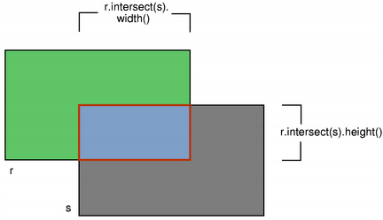

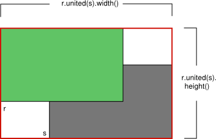

intersected()

united()

The isEmpty() function returns `true` if left() > right() or top() > bottom(). Note that an empty rectangle is not valid: The isValid() function returns `true` if left() <= right() *and* top() <= bottom(). A null rectangle (isNull() == true) on the other hand, has both width and height set to 0.

Note that due to the way QRect and QRectF are defined, an empty QRect is defined in essentially the same way as QRectF.

Finally, QRect objects can be streamed as well as compared.

### Rendering

When using an anti-aliased painter, the boundary line of a QRect will be rendered symmetrically on both sides of the mathematical rectangle's boundary line. But when using an aliased painter (the default) other rules apply.

Then, when rendering with a one pixel wide pen the QRect's boundary line will be rendered to the right and below the mathematical rectangle's boundary line.

When rendering with a two pixels wide pen the boundary line will be split in the middle by the mathematical rectangle. This will be the case whenever the pen is set to an even number of pixels, while rendering with a pen with an odd number of pixels, the spare pixel will be rendered to the right and below the mathematical rectangle as in the one pixel case.

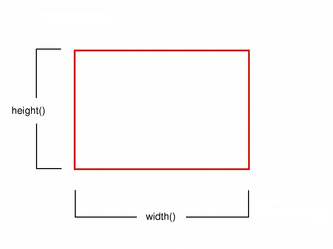

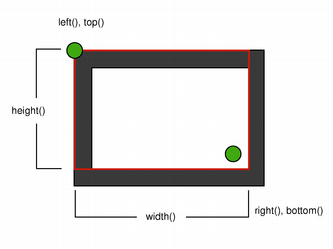

Logical representation

One pixel wide pen

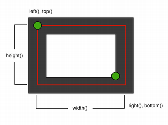

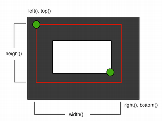

Two pixel wide pen

Three pixel wide pen

### Coordinates

The QRect class provides a collection of functions that return the various rectangle coordinates, and enable manipulation of these. QRect also provides functions to move the rectangle relative to the various coordinates.

For example the left(), setLeft() and moveLeft() functions as an example: left() returns the x-coordinate of the rectangle's left edge, setLeft() sets the left edge of the rectangle to the given x coordinate (it may change the width, but will never change the rectangle's right edge) and moveLeft() moves the entire rectangle horizontally, leaving the rectangle's left edge at the given x coordinate and its size unchanged.

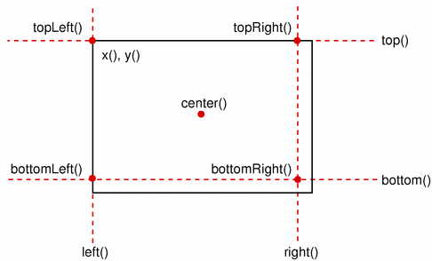

Note that for historical reasons the values returned by the bottom() and right() functions deviate from the true bottom-right corner of the rectangle: The right() function returns *left() + width() - 1* and the bottom() function returns *top() + height() - 1*. The same is the case for the point returned by the bottomRight() convenience function. In addition, the x and y coordinate of the topRight() and bottomLeft() functions, respectively, contain the same deviation from the true right and bottom edges.

We recommend that you use x() + width() and y() + height() to find the true bottom-right corner, and avoid right() and bottom(). Another solution is to use QRectF: The QRectF class defines a rectangle in the plane using floating point accuracy for coordinates, and the QRectF::right() and QRectF::bottom() functions *do* return the right and bottom coordinates.

It is also possible to add offsets to this rectangle's coordinates using the adjust() function, as well as retrieve a new rectangle based on adjustments of the original one using the adjusted() function. If either of the width and height is negative, use the normalized() function to retrieve a rectangle where the corners are swapped.

In addition, QRect provides the getCoords() function which extracts the position of the rectangle's top-left and bottom-right corner, and the getRect() function which extracts the rectangle's top-left corner, width and height. Use the setCoords() and setRect() function to manipulate the rectangle's coordinates and dimensions in one go.

### Constraints

QRect is limited to the minimum and maximum values for the `int` type. Operations on a QRect that could potentially result in values outside this range will result in undefined behavior.

**See also** QRectF and QRegion.

## Member Function Documentation

### QRect::QRect(int *x*, int *y*, int *width*, int *height*)

Constructs a rectangle with (*x*, *y*) as its top-left corner and the given *width* and *height*.

**See also** setRect().

### QRect::QRect(const QPoint &*topLeft*, const QSize &*size*)

Constructs a rectangle with the given *topLeft* corner and the given *size*.

**See also** setTopLeft() and setSize().

### QRect::QRect(const QPoint &*topLeft*, const QPoint &*bottomRight*)

Constructs a rectangle with the given *topLeft* and *bottomRight* corners, both included.

If *bottomRight* is to higher and to the left of *topLeft*, the rectangle defined is instead non-inclusive of the corners.

**Note:** To ensure both points are included regardless of relative order, use span().

**See also** setTopLeft(), setBottomRight(), and span().

### QRect::QRect()

Constructs a null rectangle.

**See also** isNull().

### void QRect::adjust(int *dx1*, int *dy1*, int *dx2*, int *dy2*)

Adds *dx1*, *dy1*, *dx2* and *dy2* respectively to the existing coordinates of the rectangle.

**See also** adjusted() and setRect().

### QRect QRect::adjusted(int *dx1*, int *dy1*, int *dx2*, int *dy2*) const

Returns a new rectangle with *dx1*, *dy1*, *dx2* and *dy2* added respectively to the existing coordinates of this rectangle.

**See also** adjust().

### int QRect::bottom() const

Returns the y-coordinate of the rectangle's bottom edge.

Note that for historical reasons this function returns top() + height() - 1; use y() + height() to retrieve the true y-coordinate.

**See also** setBottom(), bottomLeft(), and bottomRight().

### QPoint QRect::bottomLeft() const

Returns the position of the rectangle's bottom-left corner. Note that for historical reasons this function returns QPoint(left(), top() + height() - 1).

**See also** setBottomLeft(), bottom(), and left().

### QPoint QRect::bottomRight() const

Returns the position of the rectangle's bottom-right corner.

Note that for historical reasons this function returns QPoint(left() + width() -1, top() + height() - 1).

**See also** setBottomRight(), bottom(), and right().

### QPoint QRect::center() const

Returns the center point of the rectangle.

**See also** moveCenter().

### bool QRect::contains(const QPoint &*point*, bool *proper* = false) const

Returns `true` if the given *point* is inside or on the edge of the rectangle, otherwise returns `false`. If *proper* is true, this function only returns `true` if the given *point* is *inside* the rectangle (i.e., not on the edge).

**See also** intersects().

### bool QRect::contains(const QRect &*rectangle*, bool *proper* = false) const

This is an overloaded function.

Returns `true` if the given *rectangle* is inside this rectangle. otherwise returns `false`. If *proper* is true, this function only returns `true` if the *rectangle* is entirely inside this rectangle (not on the edge).

### bool QRect::contains(int *x*, int *y*) const

This is an overloaded function.

Returns `true` if the point (*x*, *y*) is inside this rectangle, otherwise returns `false`.

### bool QRect::contains(int *x*, int *y*, bool *proper*) const

This is an overloaded function.

Returns `true` if the point (*x*, *y*) is inside or on the edge of the rectangle, otherwise returns `false`. If *proper* is true, this function only returns `true` if the point is entirely inside the rectangle(not on the edge).

### void QRect::getCoords(int **x1*, int **y1*, int **x2*, int **y2*) const

Extracts the position of the rectangle's top-left corner to **x1* and **y1*, and the position of the bottom-right corner to **x2* and **y2*.

**See also** setCoords() and getRect().

### void QRect::getRect(int **x*, int **y*, int **width*, int **height*) const

Extracts the position of the rectangle's top-left corner to **x* and **y*, and its dimensions to **width* and **height*.

**See also** setRect() and getCoords().

### int QRect::height() const

Returns the height of the rectangle.

**See also** setHeight(), width(), and size().

### QRect QRect::intersected(const QRect &*rectangle*) const

Returns the intersection of this rectangle and the given *rectangle*. Note that `r.intersected(s)` is equivalent to `r & s`.

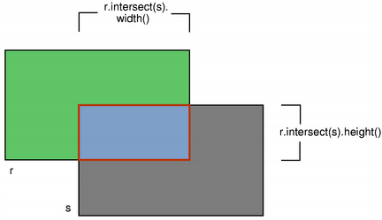

**See also** intersects(), united(), and operator&=().

### bool QRect::intersects(const QRect &*rectangle*) const

Returns `true` if this rectangle intersects with the given *rectangle* (i.e., there is at least one pixel that is within both rectangles), otherwise returns `false`.

The intersection rectangle can be retrieved using the intersected() function.

**See also** contains().

### bool QRect::isEmpty() const

Returns `true` if the rectangle is empty, otherwise returns `false`.

An empty rectangle has a left() > right() or top() > bottom(). An empty rectangle is not valid (i.e., isEmpty() == !isValid()).

Use the normalized() function to retrieve a rectangle where the corners are swapped.

**See also** isNull(), isValid(), and normalized().

### bool QRect::isNull() const

Returns `true` if the rectangle is a null rectangle, otherwise returns `false`.

A null rectangle has both the width and the height set to 0 (i.e., right() == left() - 1 and bottom() == top() - 1). A null rectangle is also empty, and hence is not valid.

**See also** isEmpty() and isValid().

### bool QRect::isValid() const

Returns `true` if the rectangle is valid, otherwise returns `false`.

A valid rectangle has a left() <= right() and top() <= bottom(). Note that non-trivial operations like intersections are not defined for invalid rectangles. A valid rectangle is not empty (i.e., isValid() == !isEmpty()).

**See also** isNull(), isEmpty(), and normalized().

### int QRect::left() const

Returns the x-coordinate of the rectangle's left edge. Equivalent to x().

**See also** setLeft(), topLeft(), and bottomLeft().

### `[since 5.1]`QRect QRect::marginsAdded(const QMargins &*margins*) const

Returns a rectangle grown by the *margins*.

This function was introduced in Qt 5.1.

**See also** operator+=(), marginsRemoved(), and operator-=().

### `[since 5.1]`QRect QRect::marginsRemoved(const QMargins &*margins*) const

Removes the *margins* from the rectangle, shrinking it.

This function was introduced in Qt 5.1.

**See also** marginsAdded(), operator+=(), and operator-=().

### void QRect::moveBottom(int *y*)

Moves the rectangle vertically, leaving the rectangle's bottom edge at the given *y* coordinate. The rectangle's size is unchanged.

**See also** bottom(), setBottom(), and moveTop().

### void QRect::moveBottomLeft(const QPoint &*position*)

Moves the rectangle, leaving the bottom-left corner at the given *position*. The rectangle's size is unchanged.

**See also** setBottomLeft(), moveBottom(), and moveLeft().

### void QRect::moveBottomRight(const QPoint &*position*)

Moves the rectangle, leaving the bottom-right corner at the given *position*. The rectangle's size is unchanged.

**See also** setBottomRight(), moveRight(), and moveBottom().

### void QRect::moveCenter(const QPoint &*position*)

Moves the rectangle, leaving the center point at the given *position*. The rectangle's size is unchanged.

**See also** center().

### void QRect::moveLeft(int *x*)

Moves the rectangle horizontally, leaving the rectangle's left edge at the given *x* coordinate. The rectangle's size is unchanged.

**See also** left(), setLeft(), and moveRight().

### void QRect::moveRight(int *x*)

Moves the rectangle horizontally, leaving the rectangle's right edge at the given *x* coordinate. The rectangle's size is unchanged.

**See also** right(), setRight(), and moveLeft().

### void QRect::moveTo(int *x*, int *y*)

Moves the rectangle, leaving the top-left corner at the given position (*x*, *y*). The rectangle's size is unchanged.

**See also** translate() and moveTopLeft().

### void QRect::moveTo(const QPoint &*position*)

Moves the rectangle, leaving the top-left corner at the given *position*.

### void QRect::moveTop(int *y*)

Moves the rectangle vertically, leaving the rectangle's top edge at the given *y* coordinate. The rectangle's size is unchanged.

**See also** top(), setTop(), and moveBottom().

### void QRect::moveTopLeft(const QPoint &*position*)

Moves the rectangle, leaving the top-left corner at the given *position*. The rectangle's size is unchanged.

**See also** setTopLeft(), moveTop(), and moveLeft().

### void QRect::moveTopRight(const QPoint &*position*)

Moves the rectangle, leaving the top-right corner at the given *position*. The rectangle's size is unchanged.

**See also** setTopRight(), moveTop(), and moveRight().

### QRect QRect::normalized() const

Returns a normalized rectangle; i.e., a rectangle that has a non-negative width and height.

If width() < 0 the function swaps the left and right corners, and it swaps the top and bottom corners if height() < 0. The corners are at the same time changed from being non-inclusive to inclusive.

**See also** isValid() and isEmpty().

### int QRect::right() const

Returns the x-coordinate of the rectangle's right edge.

Note that for historical reasons this function returns left() + width() - 1; use x() + width() to retrieve the true x-coordinate.

**See also** setRight(), topRight(), and bottomRight().

### void QRect::setBottom(int *y*)

Sets the bottom edge of the rectangle to the given *y* coordinate. May change the height, but will never change the top edge of the rectangle.

**See also** bottom() and moveBottom().

### void QRect::setBottomLeft(const QPoint &*position*)

Set the bottom-left corner of the rectangle to the given *position*. May change the size, but will never change the top-right corner of the rectangle.

**See also** bottomLeft() and moveBottomLeft().

### void QRect::setBottomRight(const QPoint &*position*)

Set the bottom-right corner of the rectangle to the given *position*. May change the size, but will never change the top-left corner of the rectangle.

**See also** bottomRight() and moveBottomRight().

### void QRect::setCoords(int *x1*, int *y1*, int *x2*, int *y2*)

Sets the coordinates of the rectangle's top-left corner to (*x1*, *y1*), and the coordinates of its bottom-right corner to (*x2*, *y2*).

**See also** getCoords() and setRect().

### void QRect::setHeight(int *height*)

Sets the height of the rectangle to the given *height*. The bottom edge is changed, but not the top one.

**See also** height() and setSize().

### void QRect::setLeft(int *x*)

Sets the left edge of the rectangle to the given *x* coordinate. May change the width, but will never change the right edge of the rectangle.

Equivalent to setX().

**See also** left() and moveLeft().

### void QRect::setRect(int *x*, int *y*, int *width*, int *height*)

Sets the coordinates of the rectangle's top-left corner to (*x*, *y*), and its size to the given *width* and *height*.

**See also** getRect() and setCoords().

### void QRect::setRight(int *x*)

Sets the right edge of the rectangle to the given *x* coordinate. May change the width, but will never change the left edge of the rectangle.

**See also** right() and moveRight().

### void QRect::setSize(const QSize &*size*)

Sets the size of the rectangle to the given *size*. The top-left corner is not moved.

**See also** size(), setWidth(), and setHeight().

### void QRect::setTop(int *y*)

Sets the top edge of the rectangle to the given *y* coordinate. May change the height, but will never change the bottom edge of the rectangle.

Equivalent to setY().

**See also** top() and moveTop().

### void QRect::setTopLeft(const QPoint &*position*)

Set the top-left corner of the rectangle to the given *position*. May change the size, but will never change the bottom-right corner of the rectangle.

**See also** topLeft() and moveTopLeft().

### void QRect::setTopRight(const QPoint &*position*)

Set the top-right corner of the rectangle to the given *position*. May change the size, but will never change the bottom-left corner of the rectangle.

**See also** topRight() and moveTopRight().

### void QRect::setWidth(int *width*)

Sets the width of the rectangle to the given *width*. The right edge is changed, but not the left one.

**See also** width() and setSize().

### void QRect::setX(int *x*)

Sets the left edge of the rectangle to the given *x* coordinate. May change the width, but will never change the right edge of the rectangle.

Equivalent to setLeft().

**See also** x(), setY(), and setTopLeft().

### void QRect::setY(int *y*)

Sets the top edge of the rectangle to the given *y* coordinate. May change the height, but will never change the bottom edge of the rectangle.

Equivalent to setTop().

**See also** y(), setX(), and setTopLeft().

### QSize QRect::size() const

Returns the size of the rectangle.

**See also** setSize(), width(), and height().

### `[static, since 6.0]`QRect QRect::span(const QPoint &*p1*, const QPoint &*p2*)

Returns a rectangle spanning the two points *p1* and *p2*, including both and everything in between.

This function was introduced in Qt 6.0.

### `[since 5.8]`CGRect QRect::toCGRect() const

Creates a CGRect from a QRect.

This function was introduced in Qt 5.8.

**See also** QRectF::fromCGRect().

### int QRect::top() const

Returns the y-coordinate of the rectangle's top edge. Equivalent to y().

**See also** setTop(), topLeft(), and topRight().

### QPoint QRect::topLeft() const

Returns the position of the rectangle's top-left corner.

**See also** setTopLeft(), top(), and left().

### QPoint QRect::topRight() const

Returns the position of the rectangle's top-right corner.

Note that for historical reasons this function returns QPoint(left() + width() -1, top()).

**See also** setTopRight(), top(), and right().

### void QRect::translate(int *dx*, int *dy*)

Moves the rectangle *dx* along the x axis and *dy* along the y axis, relative to the current position. Positive values move the rectangle to the right and down.

**See also** moveTopLeft(), moveTo(), and translated().

### void QRect::translate(const QPoint &*offset*)

This is an overloaded function.

Moves the rectangle *offset*.x() along the x axis and *offset*.y() along the y axis, relative to the current position.

### QRect QRect::translated(int *dx*, int *dy*) const

Returns a copy of the rectangle that is translated *dx* along the x axis and *dy* along the y axis, relative to the current position. Positive values move the rectangle to the right and down.

**See also** translate().

### QRect QRect::translated(const QPoint &*offset*) const

This is an overloaded function.

Returns a copy of the rectangle that is translated *offset*.x() along the x axis and *offset*.y() along the y axis, relative to the current position.

### `[since 5.7]`QRect QRect::transposed() const

Returns a copy of the rectangle that has its width and height exchanged:

```
QRect r = {15, 51, 42, 24};
r = r.transposed(); // r == {15, 51, 24, 42}
```

This function was introduced in Qt 5.7.

**See also** QSize::transposed().

### QRect QRect::united(const QRect &*rectangle*) const

Returns the bounding rectangle of this rectangle and the given *rectangle*.

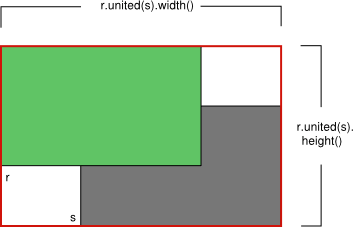

**See also** intersected().

### int QRect::width() const

Returns the width of the rectangle.

**See also** setWidth(), height(), and size().

### int QRect::x() const

Returns the x-coordinate of the rectangle's left edge. Equivalent to left().

**See also** setX(), y(), and topLeft().

### int QRect::y() const

Returns the y-coordinate of the rectangle's top edge. Equivalent to top().

**See also** setY(), x(), and topLeft().

### QRect QRect::operator&(const QRect &*rectangle*) const

Returns the intersection of this rectangle and the given *rectangle*. Returns an empty rectangle if there is no intersection.

**See also** operator&=() and intersected().

### QRect &QRect::operator&=(const QRect &*rectangle*)

Intersects this rectangle with the given *rectangle*.

**See also** intersected() and operator&().

### `[since 5.1]`QRect &QRect::operator+=(const QMargins &*margins*)

Adds the *margins* to the rectangle, growing it.

This function was introduced in Qt 5.1.

**See also** marginsAdded(), marginsRemoved(), and operator-=().

### `[since 5.1]`QRect &QRect::operator-=(const QMargins &*margins*)

Returns a rectangle shrunk by the *margins*.

This function was introduced in Qt 5.1.

**See also** marginsRemoved(), operator+=(), and marginsAdded().

### QRect QRect::operator|(const QRect &*rectangle*) const

Returns the bounding rectangle of this rectangle and the given *rectangle*.

**See also** operator|=() and united().

### QRect &QRect::operator|=(const QRect &*rectangle*)

Unites this rectangle with the given *rectangle*.

**See also** united() and operator|().

## Related Non-Members

### bool operator!=(const QRect &*r1*, const QRect &*r2*)

Returns `true` if the rectangles *r1* and *r2* are different, otherwise returns `false`.

### `[since 5.1]`QRect operator+(const QRect &*rectangle*, const QMargins &*margins*)

Returns the *rectangle* grown by the *margins*.

This function was introduced in Qt 5.1.

### `[since 5.1]`QRect operator+(const QMargins &*margins*, const QRect &*rectangle*)

This is an overloaded function.

Returns the *rectangle* grown by the *margins*.

This function was introduced in Qt 5.1.

### `[since 5.3]`QRect operator-(const QRect &*lhs*, const QMargins &*rhs*)

Returns the *lhs* rectangle shrunk by the *rhs* margins.

This function was introduced in Qt 5.3.

### QDataStream &operator<<(QDataStream &*stream*, const QRect &*rectangle*)

Writes the given *rectangle* to the given *stream*, and returns a reference to the stream.

**See also** Serializing Qt Data Types.

### bool operator==(const QRect &*r1*, const QRect &*r2*)

Returns `true` if the rectangles *r1* and *r2* are equal, otherwise returns `false`.

### QDataStream &operator>>(QDataStream &*stream*, QRect &*rectangle*)

Reads a rectangle from the given *stream* into the given *rectangle*, and returns a reference to the stream.

**See also** Serializing Qt Data Types.

© The Qt Company Ltd  
Licensed under the GNU Free Documentation License, Version 1.3.  
https://doc.qt.io/qt-6.2/qrect.html